# Análise de Sistemas em Tempo Contínuo no Domínio do Tempo

## Resposta ao Impulso

Quando estudarmos a resposta de estado nulo, veremos que a resposta para qualquer função de entrada pode ser determinada através da integral de convolução, se conhecermos a resposta do sistema à uma entrada impulsiva.

Vamos substituir $x(t)=\delta(t)$ em $Q(D)y(t)=P(D)x(t)$. Também definimos $h(t)$ como a resposta ao impulso. Ainda, vamos inicialmente considerar $N=M$. Então, temos

\begin{equation*} Q(D)h(t)=P(D)\delta(t) \label{} \tag{1} \end{equation*}

ou

\begin{equation*} (D^N+a_1D^{N-1}+ ...+ a_N)h(t)=(b_0D^N+b_1D^{N-1}+...+b_N)\delta(t) \label{} \tag{2} \end{equation*}

No momento em que ocorre a entrada impulsiva ocorrerá o armazenamento súbito de energia no sistema, e imediatamente após (denotaremos este tempo por $0^+$), este impulso se extingue, e o sistema responde como na resposta de entrada nula, mas com condições iniciais alteradas pelo impulso. Portanto, a resposta $h(t)$ contém termos relativos a resposta impulsiva e termos baseados nos modos característicos, quando a entrada impulsiva não está mais presente.

\begin{equation*} h(t)=A\delta(t) + \sum_{}^{} c_i e^{\lambda_i t}. \label{} \tag{3} \end{equation*}

Substituindo (3) em (2), as derivadas dos termos impulsivos nos dois lados da equação devem coincidir. Então

$$D^NA\delta(t)=D^Nb_0\delta(t) \rightarrow A=b_0.$$

Por outro lado, se $M<N$, $A=b_0=0$ e $h(t)$ conterá apenas os modos característicos do sistema. Como vimos, a determinação da resposta baseada nos modos característicos é obtida através das novas condições iniciais impostas pela entrada impulsiva.

Sejam os dois sistemas $S$ e $S_0$ definidos abaixo:

$$\quad S:Q(D)y(t)=P(D)x(t)$$

e

$$ S_0:Q(D)w(t)=x(t).$$

Claramente, $S$ e $S_0$ possuem os mesmos modos característicos, por possuirem o mesmo polinômio característico. No sistema $S_0$, usamos $x(t)=\delta(t)$ e $w(t)=y_n(t)$. Para $t>0$ teremos

\begin{equation*} Q(D)y_n(t)=0, \label{} \tag{4} \end{equation*}

ou seja, um típico problema de entrada nula. E quais são as condições iniciais? A resposta é $y^{N-1}(0^+)=1,\; y^{N-2}(0^+)=y^{N-3}(0^+)=...=y(0^+)=0$. Se tivéssemos por exemplo, $y^{N-2}(0^+)=1$. então teríamos também que ter $y^{N-1}(0^+)=\delta(t)$, pois a derivada do degrau é um impulso e daí ficaríamos com $y^{N}(0^+)=\delta(t)'$,a derivada do impulso, termo inexistente na entrada. Mais concretamente, considere a seguinte equação diferencial, descrevendo um sistema inicialmente em estado de equilíbrio, ou seja, relaxado:

$$ (D^2+3D+2)y_n(t)=\delta(t).$$

Inicialmente $y_n(t)$ e todas suas derivadas são nulas, porque o sistema é relaxado. Em $t=0$, o impulso muda o estado de $y_n'(0)$ para 1, portanto, $y_n(t)'$ é descrito pela função degrau unitário, 0 para $t<0$ e 1 para $t>1$. Além disso, a derivada do degrau unitário é o impulso $(D^2y_n(t)=Dy_n(t)=\delta(t))$, o que está de acordo com a equação diferencial original.

Portanto, com a equação (4) e as condições iniciais acima descritas, encontramos os modos característicos para o sistema $S_0$ onde $x(t)=\delta(t)$ e $w(t)=y_n(t)$. Ainda, em $S_0$, podemos multiplicar $w(t)$ e $x(t)$ pelo polinômio $P(D)$, de forma a ter

$$Q(D)P(D)w(t)=P(D)x(t)$$

e comparando com $S$, é necessário que $y(t)=P(D)w(t)$. Da mesma forma, se em $S$ e $S_0$ $x(t)=\delta(t),\;w(t)=y_n(t)\;e\;y(t)=h(t)$,

$$ h(t)=P(D)y_n(t)$$

Essa é a parcela da resposta ao impulso contendo os modos característicos. A resposta ao impulso total é

$$ h(t)=b_0\delta(t)+P(D)y_n(t).$$

**Exemplo** Seja o sistema $(D^2+3D+2)y(t)=(3D^2+1)x(t)$, e uma entrada impulsiva $x(t)=\delta(t)$. Determine a resposta.

Inicialmente, podemos verificar que $M=N=2$ e $A=3$. Portanto

$$h(t)=3\delta(t) +\sum_{}^{} c_ie^{\lambda_i(t)}.$$

precisamos agora determinar os modos característicos de $h(t)$. Para isso resolveremos o seguinte problema:

$$(D^2+3D+2)y_n(t)=0$$

com as condições iniciais $y_n(0^+)=0,\;y_n(0^+)'=1$. As raízes da equação característica são $\lambda_1=-1\;\mbox{e}\;\lambda_2=-2$. Então

$$y_n(t)=c_1e^{-t}+c_2e^{-2t}.$$

Inserindo as condições iniciais encontramos $c_1=1\;\mbox{e}\;c_2=-1$. Assim, a resposta ao impulso é

$$h(t)=3\delta(t)+(4e^{-t}-13e^{-2t})u(t).$$

Com o pequeno *script* abaixo podemos fazer o gráfico da resposta baseada nos modos característicos para $t>0^+$.

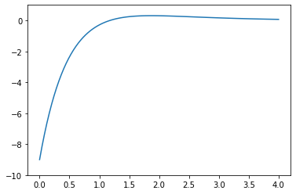

```python
import numpy as np
import matplotlib.pyplot as plt

t=np.linspace(0,4,100)
h= (4*np.exp(-t)-13*np.exp(-2*t))

plt.plot(t,h)
plt.ylim([-10,1]);
```